# HW3

### Question 4

I have made the decomposition on Question 2 and found a stationary detrend remaining result. Let’s examine the detrend part and determine a MA model with a lowest AIC value.

For the MA model, my main concern will be the partial autocorrelation plot.

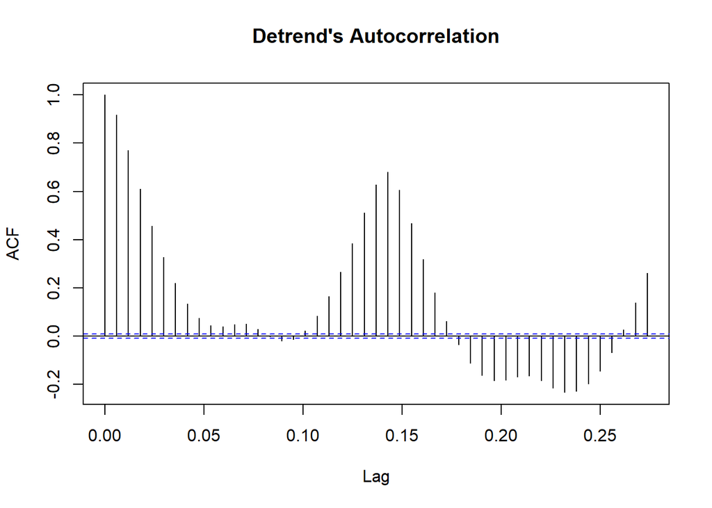

```r
acf(random_add_final, na.action = na.pass, main= "Detrend's Autocorrelation")
```

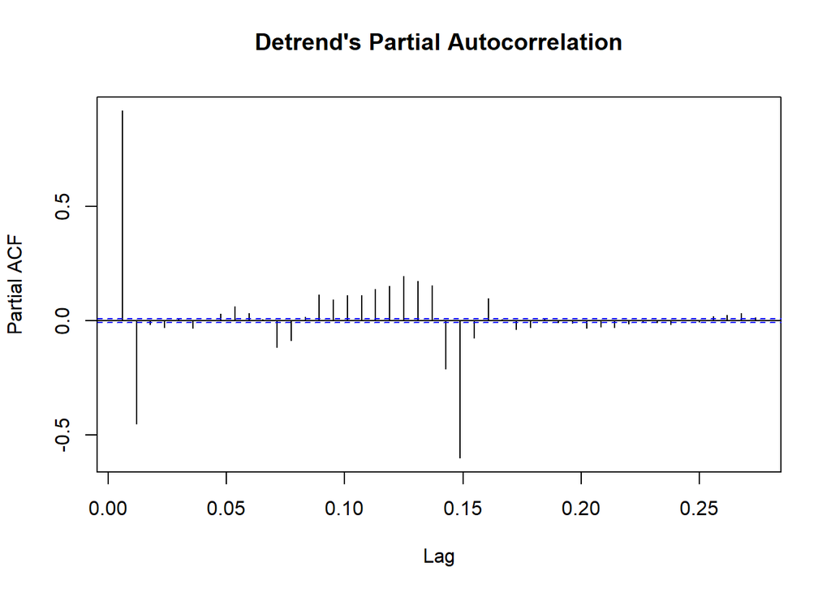

```r
pacf(random_add_final, na.action = na.pass, main = "Detrend's Partial Autocorrelation")
```

We see a significant partial autocorrelation till lag 2 so I will try my trials with MA(2)

```r
model <- arima(random_add_final, order=c(0,0,2))
print(model)
```

```
##
## Call:
## arima(x = random_add_final, order = c(0, 0, 2))
##
## Coefficients:
##          ma1     ma2  intercept
##       1.2026  0.6142    -0.0011
## s.e.  0.0037  0.0029     0.0089
##
## sigma^2 estimated as 0.4658:  log likelihood = -48777.75,  aic = 97563.5
```

```r
AIC(model)
```

```
## [1] 97563.5
```

```r
BIC(model)
```

```
## [1] 97598.54
```

As AR(10) performed the best, I will try MA(10) to see the success of the model.

```r
model <- arima(random_add_final, order=c(0,0,10))
print(model)
```

```
##
## Call:
## arima(x = random_add_final, order = c(0, 0, 10))
##
## Coefficients:
##          ma1     ma2     ma3     ma4     ma5     ma6     ma7     ma8     ma9
##       1.3209  1.3180  1.2083  1.0176  0.8467  0.6906  0.5430  0.3660  0.1985
## s.e.  0.0046  0.0076  0.0096  0.0108  0.0117  0.0124  0.0124  0.0109  0.0080
##         ma10  intercept
##       0.0361    -0.0011
## s.e.  0.0049     0.0205
##
## sigma^2 estimated as 0.2718:  log likelihood = -36107.56,  aic = 72239.11
```

```r
AIC(model)
```

```
## [1] 72239.11
```

```r
BIC(model)
```

```
## [1] 72344.22
```

As MA(10) was better than MA(2), we can increase to MA(11) and compare AIC.

```r
model <- arima(random_add_final, order=c(0,0,11))
print(model)
```

```
##
## Call:
## arima(x = random_add_final, order = c(0, 0, 11))
##
## Coefficients:
##          ma1     ma2     ma3     ma4     ma5     ma6     ma7     ma8     ma9
##       1.3209  1.3131  1.1849  0.9627  0.7629  0.5929  0.4404  0.2538  0.0727
## s.e.  0.0047  0.0078  0.0097  0.0111  0.0125  0.0134  0.0145  0.0147  0.0141
##          ma10     ma11  intercept
##       -0.0810  -0.0568    -0.0011
## s.e.   0.0121   0.0054     0.0186
##
## sigma^2 estimated as 0.2711:  log likelihood = -36044.87,  aic = 72115.73
```

```r
AIC(model)
```

```
## [1] 72115.73
```

```r
BIC(model)
```

```
## [1] 72229.59
```

As it is lower than MA(10), let’s try MA(12).

```r
model <- arima(random_add_final, order=c(0,0,12))
print(model)
```

```
##
## Call:
## arima(x = random_add_final, order = c(0, 0, 12))
##
## Coefficients:
##          ma1     ma2     ma3     ma4     ma5     ma6     ma7     ma8     ma9
##       1.3009  1.3113  1.2207  0.9943  0.7706  0.5787  0.4158  0.2177  0.0212
## s.e.  0.0048  0.0077  0.0097  0.0113  0.0117  0.0119  0.0138  0.0155  0.0143
##          ma10    ma11    ma12  intercept
##       -0.1361  0.0323  0.1345    -0.0011
## s.e.   0.0104  0.0070  0.0051     0.0188
##
## sigma^2 estimated as 0.2683:  log likelihood = -35800.59,  aic = 71629.17
```

```r
AIC(model)
```

```
## [1] 71629.17
```

```r
BIC(model)
```

```
## [1] 71751.79
```

MA(12) is better than MA(11). However as the number increases the computational weight on my computer, I will stop here and say MA(12) is the best fit here.

### Question 5

As I have found the best AR and MA models let’S combine them and determine the best, result and use it to calculate the error. Overall the lowest AIC value was with MA(12), it is the best.

Let’s combine AR(10) and MA(12) and see whether the model will improve.

```r
model <- arima(random_add_final, order=c(10,0,12))
print(model)
```

```
##
## Call:
## arima(x = random_add_final, order = c(10, 0, 12))
##
## Coefficients:
##          ar1     ar2     ar3     ar4      ar5      ar6     ar7     ar8     ar9
##       0.4525  0.4697  0.3731  0.1688  -0.8684  -0.2139  0.0454  0.4023  0.8362
## s.e.  0.0073  0.0016  0.0027  0.0039   0.0046   0.0039  0.0038  0.0029  0.0006
##          ar10     ma1     ma2      ma3      ma4      ma5     ma6     ma7
##       -0.6690  0.8731  0.3231  -0.3290  -0.8418  -0.1071  0.4236  0.5933
## s.e.   0.0069  0.0088  0.0129   0.0106   0.0048   0.0107  0.0069  0.0052
##          ma8      ma9     ma10     ma11     ma12  intercept
##       0.1904  -0.8885  -0.6256  -0.4276  -0.1832      5e-04
## s.e.  0.0097   0.0052   0.0090   0.0120   0.0088      8e-04
##
## sigma^2 estimated as 0.2255:  log likelihood = -31726.17,  aic = 63500.35
```

```r
AIC(model)
```

```
## [1] 63500.35
```

```r
BIC(model)
```

```
## [1] 63710.56
```

Let’s try ARMA (1,0,1) to compare performance with my best option.

```r
model <- arima(random_add_final, order=c(1,0,1))
print(model)
```

```
##
## Call:
## arima(x = random_add_final, order = c(1, 0, 1))
##
## Coefficients:
##          ar1     ma1  intercept
##       0.8668  0.4176    -0.0011
## s.e.  0.0024  0.0040     0.0263
##
## sigma^2 estimated as 0.2881:  log likelihood = -37475.2,  aic = 74958.41
```

```r
AIC(model)
```

```
## [1] 74958.41
```

```r
BIC(model)
```

```
## [1] 74993.44
```

This is much higher than ARMA(10,0,12). I will continue my prediction with this model as it gives me the lowest AIC value among all of them.

```r
model_final <- arima(random_add_final, order=c(10,0,12))
print(model_final)
```

```
##
## Call:
## arima(x = random_add_final, order = c(10, 0, 12))
##
## Coefficients:
##          ar1     ar2     ar3     ar4      ar5      ar6     ar7     ar8     ar9
##       0.4525  0.4697  0.3731  0.1688  -0.8684  -0.2139  0.0454  0.4023  0.8362
## s.e.  0.0073  0.0016  0.0027  0.0039   0.0046   0.0039  0.0038  0.0029  0.0006
##          ar10     ma1     ma2      ma3      ma4      ma5     ma6     ma7
##       -0.6690  0.8731  0.3231  -0.3290  -0.8418  -0.1071  0.4236  0.5933
## s.e.   0.0069  0.0088  0.0129   0.0106   0.0048   0.0107  0.0069  0.0052
##          ma8      ma9     ma10     ma11     ma12  intercept
##       0.1904  -0.8885  -0.6256  -0.4276  -0.1832      5e-04
## s.e.  0.0097   0.0052   0.0090   0.0120   0.0088      8e-04
##
## sigma^2 estimated as 0.2255:  log likelihood = -31726.17,  aic = 63500.35
```

```r
AIC(model_final)
```

```
## [1] 63500.35
```

```r
BIC(model_final)
```

```
## [1] 63710.56
```

To see the performance of the final model, let’s the random and predicted on the same graph.

```r
model_fitted <- random_add_final - residuals(model_final)


detrend = cbind(random_add_final, residuals(model_final))
detrend = as.data.table(detrend)
detrend = detrend[,date:= data$date]
names(detrend) = c("detrend","prediction","date")
```

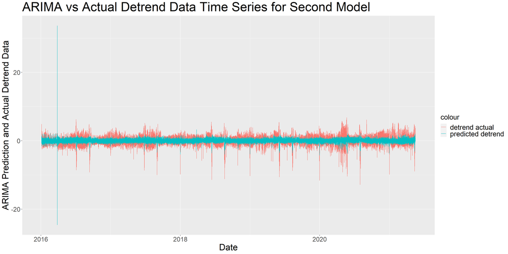

```r
ggplot(detrend, aes(x=date)) + geom_line(aes(y=detrend)) +
  geom_line(aes(y=detrend,color='detrend actual')) +
  geom_line(aes(y=prediction,color='predicted detrend')) +
  xlab("Date") + ylab("ARIMA Prediction and Actual Detrend Data") + ggtitle("ARIMA vs Actual Detrend Data Time Series for Second Model") + theme(title = element_text(size = 30)) + theme(axis.title.x = element_text(size = 25)) + theme(axis.title.y=element_text(size = 25)) + theme(axis.text.x = element_text(size = 18)) + theme(axis.text.y = element_text(size = 18))  + theme(
  legend.title = element_text(size = 20),
  legend.text = element_text(size = 20)
  )
```

It seems we have we have predict under the random error. This is due to the ARIMA Model. Let’s see how we perform on the original data.

```r
detrend = detrend[,model_prediction:= data_add_2$trend + data_add_2$seasonal + prediction]
detrend = detrend[,actual:= data$cons]
```

Plotting the graph:

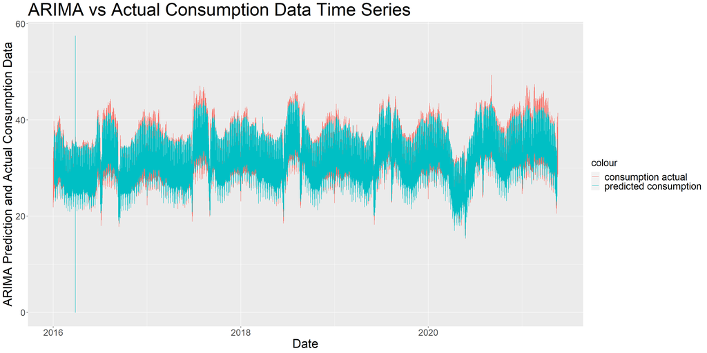

```r
ggplot(detrend, aes(x=date))  +
  geom_line(aes(y=actual,color='consumption actual')) +
  geom_line(aes(y=model_prediction,color='predicted consumption')) +
  xlab("Date") + ylab("ARIMA Prediction and Actual Consumption Data") + ggtitle("ARIMA vs Actual Consumption Data Time Series") + theme(title = element_text(size = 30)) + theme(axis.title.x = element_text(size = 25)) + theme(axis.title.y=element_text(size = 25)) + theme(axis.text.x = element_text(size = 18)) + theme(axis.text.y = element_text(size = 18))  + theme(
  legend.title = element_text(size = 20),
  legend.text = element_text(size = 20)
  )
```

It is a much better fit compared to the error. Here the hourly data turned into the days. We also examine the daily groups to discuss and also add the last prediction values.

```r
model_forecast <- predict(model_final, n.ahead = 84)$pred
```

This prediction is for the detrend part. I will use last trend value and seasonal component to forecast the data.

```r
last_trend <- tail(data_add_2$trend[!is.na(data_add_2$trend)],1)

detrend = detrend[,last_trend := as.numeric(last_trend)]
detrend = detrend[,seasonality := as.numeric(data_add_2$seasonal)]

prediction_needed = detrend[47125:.N,]
model_forecast <- predict(model_final, n.ahead = 84)$pred

prediction_needed = prediction_needed[,prediction := predict(model_final, n.ahead = 84)$pred]

prediction_needed = prediction_needed[,last_forecast := prediction + last_trend + seasonality]

detrend$model_prediction[47125:47208]  <- prediction_needed$last_forecast
```

Plotting with the predictions.

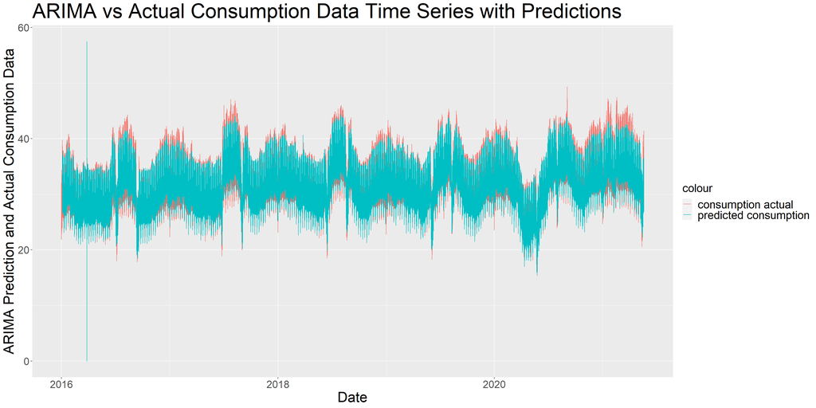

```r
ggplot(detrend, aes(x=date))  +
  geom_line(aes(y=actual,color='consumption actual')) +
  geom_line(aes(y=model_prediction,color='predicted consumption')) +
  xlab("Date") + ylab("ARIMA Prediction and Actual Consumption Data") + ggtitle("ARIMA vs Actual Consumption Data Time Series with Predictions") + theme(title = element_text(size = 30)) + theme(axis.title.x = element_text(size = 25)) + theme(axis.title.y=element_text(size = 25)) + theme(axis.text.x = element_text(size = 18)) + theme(axis.text.y = element_text(size = 18))  + theme(
  legend.title = element_text(size = 20),
  legend.text = element_text(size = 20)
  )
```

Let’s convert the data to the daily version to evaluate.

```r
daily_actual=detrend[,list(mean_consumption_actual = mean(actual,na.rm=T)), by=list(date)]
daily_prediction=detrend[,list(mean_consumption_pred = mean(model_prediction,na.rm=T)), by=list(date)]

daily_actual = daily_actual[,daily_prediction := daily_prediction$mean_consumption_pred]

daily_actual_last = tail(daily_actual,15)

daily_actual_last$daily_prediction <- as.numeric(daily_actual_last$daily_prediction)

str(daily_actual_last)
```

```
## Classes 'data.table' and 'data.frame':   15 obs. of  3 variables:
##  $ date                   : Date, format: "2021-05-06" "2021-05-07" ...
##  $ mean_consumption_actual: num  35.9 35.2 34.5 31.5 33.4 ...
##  $ daily_prediction       : num  36 35.5 33.7 29.7 32.2 ...
##  - attr(*, ".internal.selfref")=<externalptr>
```

Let’s plot daily versions.

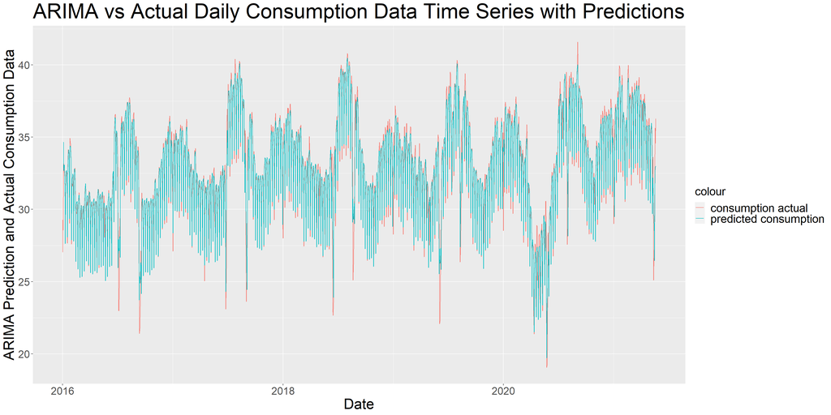

```r
ggplot(daily_actual, aes(x=date))  +
  geom_line(aes(y=mean_consumption_actual,color='consumption actual')) +
  geom_line(aes(y=daily_prediction,color='predicted consumption')) +
  xlab("Date") + ylab("ARIMA Prediction and Actual Consumption Data") + ggtitle("ARIMA vs Actual Daily Consumption Data Time Series with Predictions") + theme(title = element_text(size = 30)) + theme(axis.title.x = element_text(size = 25)) + theme(axis.title.y=element_text(size = 25)) + theme(axis.text.x = element_text(size = 18)) + theme(axis.text.y = element_text(size = 18))  + theme(
  legend.title = element_text(size = 20),
  legend.text = element_text(size = 20)
  )
```

Daily fit is impressive, we have made very similar forecast to the original data.

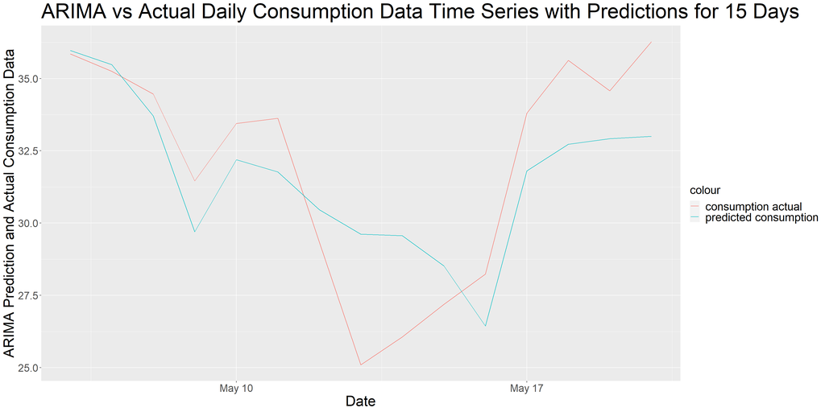

```r
ggplot(daily_actual_last, aes(x=date))  +
  geom_line(aes(y=mean_consumption_actual,color='consumption actual')) +
  geom_line(aes(y=daily_prediction,color='predicted consumption')) +
  xlab("Date") + ylab("ARIMA Prediction and Actual Consumption Data") + ggtitle("ARIMA vs Actual Daily Consumption Data Time Series with Predictions for 15 Days") + theme(title = element_text(size = 30)) + theme(axis.title.x = element_text(size = 25)) + theme(axis.title.y=element_text(size = 25)) + theme(axis.text.x = element_text(size = 18)) + theme(axis.text.y = element_text(size = 18))  + theme(
  legend.title = element_text(size = 20),
  legend.text = element_text(size = 20)
  )
```

As trend we use the same value for all the next data, this may result a bit problematic. We don’t catch the trend in every point.

To see the model evaluation, I am using the function from the lecture hours.

```r
accu=function(actual,forecast){
  n=length(actual)
  error=actual-forecast
  mean=mean(actual)
  sd=sd(actual)
  CV=sd/mean
  FBias=sum(error)/sum(actual)
  MAPE=sum(abs(error/actual))/n
  RMSE=sqrt(sum(error^2)/n)
  MAD=sum(abs(error))/n
  MADP=sum(abs(error))/sum(abs(actual))
  WMAPE=MAD/mean
  l=data.frame(n,mean,sd,CV,FBias,MAPE,RMSE,MAD,MADP,WMAPE)
  return(l)
}
```

The function will give me my error metrics.

```r
accu(daily_actual_last$mean_consumption_actual, daily_actual_last$daily_prediction)
```

```
##    n     mean       sd       CV      FBias       MAPE     RMSE      MAD
## 1 15 32.01935 3.827433 0.119535 0.01339431 0.06162372 2.214905 1.871572
##         MADP      WMAPE
## 1 0.05845128 0.05845128
```

My FBias and MAPE is quite low. Lower than lecture examples. My statistics overall suggest that my model is fine.

### Conclusion

In this HW3, first of all I have examined the possible seasonalities that electricity consumption data may have. My data shows hourly, weekly, monthly seasonality. I have explained the possible reasons for this kind of trends. Such as closed workplaces during Sundays for weekly trend, air conditioning during summer for monthly trend. Special days limits my time series analysis, as they create outliers and damage my models accuracy. For the next part, I have examined 168 hour data, create AR, MA and ARIMA models. The model was the lowest AIC value is ARIMA(10,0,12). I have used that model in my predictions and obtained a prediction that performed acceptably in the forecast.